# F70TS Machine learning

# Week 8 Lab

# Implementing and Evaluating k-Nearest Neighbors (kNN)

### Objective:

The goal of this lab is to understand the k-Nearest Neighbors (kNN) algorithm, implement it, and evaluate its performance on a dataset. You will explore how the value of k, distance metrics, and data normalization impact the model's performance.

We will use the Wine dataset. You can check details about this dataset [here](https://www.geeksforgeeks.org/wine-dataset/).

#### Question

- Show the names of the features and the 10 first rows

```python
# Import necessary libraries
import numpy as np
import pandas as pd
from sklearn.datasets import load_wine


# Load the dataset
wine = load_wine()
data = pd.DataFrame(wine.data, columns=wine.feature_names)
data["target"] = wine.target

# Answer the question here
```

```python
data.head(n=10)
```

|  | alcohol | malic_acid | ash | alcalinity_of_ash | magnesium | total_phenols | flavanoids | nonflavanoid_phenols | proanthocyanins | color_intensity | hue | od280/od315_of_diluted_wines | proline | target |
| --- | --- | --- | --- | --- | --- | --- | --- | --- | --- | --- | --- | --- | --- | --- |
| 0 | 14.23 | 1.71 | 2.43 | 15.6 | 127.0 | 2.80 | 3.06 | 0.28 | 2.29 | 5.64 | 1.04 | 3.92 | 1065.0 | 0 |
| 1 | 13.20 | 1.78 | 2.14 | 11.2 | 100.0 | 2.65 | 2.76 | 0.26 | 1.28 | 4.38 | 1.05 | 3.40 | 1050.0 | 0 |
| 2 | 13.16 | 2.36 | 2.67 | 18.6 | 101.0 | 2.80 | 3.24 | 0.30 | 2.81 | 5.68 | 1.03 | 3.17 | 1185.0 | 0 |
| 3 | 14.37 | 1.95 | 2.50 | 16.8 | 113.0 | 3.85 | 3.49 | 0.24 | 2.18 | 7.80 | 0.86 | 3.45 | 1480.0 | 0 |
| 4 | 13.24 | 2.59 | 2.87 | 21.0 | 118.0 | 2.80 | 2.69 | 0.39 | 1.82 | 4.32 | 1.04 | 2.93 | 735.0 | 0 |
| 5 | 14.20 | 1.76 | 2.45 | 15.2 | 112.0 | 3.27 | 3.39 | 0.34 | 1.97 | 6.75 | 1.05 | 2.85 | 1450.0 | 0 |
| 6 | 14.39 | 1.87 | 2.45 | 14.6 | 96.0 | 2.50 | 2.52 | 0.30 | 1.98 | 5.25 | 1.02 | 3.58 | 1290.0 | 0 |
| 7 | 14.06 | 2.15 | 2.61 | 17.6 | 121.0 | 2.60 | 2.51 | 0.31 | 1.25 | 5.05 | 1.06 | 3.58 | 1295.0 | 0 |
| 8 | 14.83 | 1.64 | 2.17 | 14.0 | 97.0 | 2.80 | 2.98 | 0.29 | 1.98 | 5.20 | 1.08 | 2.85 | 1045.0 | 0 |
| 9 | 13.86 | 1.35 | 2.27 | 16.0 | 98.0 | 2.98 | 3.15 | 0.22 | 1.85 | 7.22 | 1.01 | 3.55 | 1045.0 | 0 |

### Task 2: Splitting the dataset and scaling

Next, we split the data into training and test sets, and normalize the data to ensure that the kNN algorithm performs optimally.

#### Questions

- Apply the Standard Scaler to normalise the data.
- Explain the difference bewteen normalising the train and the test data

```python
from sklearn.model_selection import train_test_split
from sklearn.preprocessing import StandardScaler

#data
X = wine.data
y= wine.target

# Split the data into training and test sets
X_train, X_test, y_train, y_test = train_test_split(X, y, test_size=0.3, random_state=42)

# Normalize the data: include your code here
```

```python
scaler = StandardScaler()
X_train = scaler.fit_transform(X_train)
X_test = scaler.transform(X_test)

print(X_train[:10])
```

```
[[ 0.62844732  1.08120605 -0.65212742  0.         -0.8414766  -1.00335756
  -1.51706225  1.71144809 -1.23077056  0.33317435 -0.64137827 -1.07090115
  -0.51821917]
 [-0.54088231 -0.61299439 -1.42753372  0.28817977 -1.03748743 -0.11258512
  -0.08675106 -0.35047592 -0.19503558 -0.93349517  0.34652993  1.33076844
  -0.21506322]
 [-0.75565714 -1.28703113 -1.53830605 -1.35444491  2.29469668 -0.57332948
  -0.15628008 -0.11256161  2.01453238 -0.72238359  0.43243499 -0.39843366
   0.04196031]
 [ 0.37787668 -0.69497183  1.7479397  -1.15271907  0.59593615  0.50174071
   0.6681354  -0.19186638 -0.40218258 -0.1716577   0.56129258  0.24658617
   0.47033286]
 [-0.80338488  0.3889521  -0.54135509 -0.43226965 -0.8414766   0.27136852
   0.24102858 -0.9056093   0.68533915 -1.29605638  0.81900777  0.96022513
  -1.47381948]
 [ 0.89094989 -0.49458253 -0.02441756 -0.83572132  0.00790366  0.51709885
   0.86678973 -0.74699976  0.16747166 -0.53880829  0.64719764  1.92089296
   0.98108475]
 [ 1.09379278  2.4019537  -0.50443098  0.14408988 -1.36417215 -1.98627887
  -1.65612029  0.28396224 -1.57601555 -0.03397623 -1.62928647 -1.74336863
  -1.06192279]
 [-0.80338488 -0.90446974 -1.42753372 -1.00862919 -1.03748743  0.42494998
   0.4893465  -0.58839022  0.30556966 -0.9518527   1.16262801  0.19169086
  -1.01908554]
 [-0.89884036 -1.10485904 -2.27678823 -0.77808537  3.27475083 -0.65012021
  -0.72244493 -1.77796176  1.56571389 -0.97479961  1.37739066  0.64457713
  -0.06348524]
 [-0.17099233  0.88081675 -0.24596221  0.         -0.8414766  -1.2183716
  -1.33827335  0.28396224 -1.07541031  2.4259327  -1.02795104 -1.16696793
  -0.17222596]]
```

The standard scaler is simply $z = \frac{x - \bar{x}}{SD(x)}$

### Task 3: Implementing kNN with k=3

We will implement the k-Nearest Neighbors algorithm with k=3 and evaluate the model's performance.

```python
from sklearn.neighbors import KNeighborsClassifier
from sklearn.metrics import classification_report

# Create the kNN model
knn = KNeighborsClassifier(n_neighbors=3)
knn.fit(X_train, y_train)

# Make predictions and evaluate the model
y_pred = knn.predict(X_test)
print(classification_report(y_test, y_pred, target_names=wine.target_names))
```

```
              precision    recall  f1-score   support

     class_0       0.95      1.00      0.97        19
     class_1       1.00      0.90      0.95        21
     class_2       0.93      1.00      0.97        14

    accuracy                           0.96        54
   macro avg       0.96      0.97      0.96        54
weighted avg       0.97      0.96      0.96        54
```

The target variable `wine class` has three categories: `class 0` (wine from cultivar 1), `class 1` (wine from cultivar 2), and `class 2` (wine from cultivar 3). The k-Nearest Neighbors model with `k=3` achieved strong performance across all classes, with an overall accuracy of 96% (52 out of 54 test wines were correctly classified).

### Task 4: Trying the Manhattan distance

We'll compare the performance of kNN using different distance metrics: Euclidean and Manhattan.

#### Questions

- Implemet the kNN model with the manhattan distance (instead of the Eucliden)
- Show the performance of the model on the test data

```python
# Add your code here
# Implement kNN with Manhattan distance
knn_manhattan = KNeighborsClassifier(n_neighbors=3, metric='manhattan')
knn_manhattan.fit(X_train, y_train)
y_pred_manhattan = knn_manhattan.predict(X_test)

# Evaluate the model with Manhattan distance
print("Manhattan Distance Metrics:")
print(classification_report(y_test, y_pred_manhattan, target_names=wine.target_names))
```

```
Manhattan Distance Metrics:
              precision    recall  f1-score   support

     class_0       0.95      1.00      0.97        19
     class_1       1.00      0.90      0.95        21
     class_2       0.93      1.00      0.97        14

    accuracy                           0.96        54
   macro avg       0.96      0.97      0.96        54
weighted avg       0.97      0.96      0.96        54
```

It looks like we get the very same result.

### Task 5: Investigating the effect of different k values

We now test how the value of k (number of neighbors) affects the accuracy of the model. We apply this experience with the two distances Euclidean and Manhatan and we plot the accuracies against k.

#### Questions

- Plot together the accuracies of the Euclidean and Manhattan kNN again k

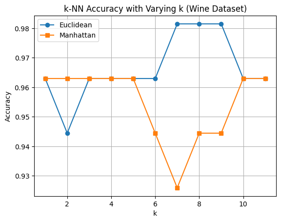

```python
import matplotlib.pyplot as plt

# Test for different values of k and compare Euclidean and Manhattan distances
k_values = range(1, 12)
euclidean_accuracies = []
manhattan_accuracies = []

for k in k_values:
    # Euclidean distance
    knn_euclidean = KNeighborsClassifier(n_neighbors=k, metric='euclidean')
    knn_euclidean.fit(X_train, y_train)
    euclidean_accuracies.append(knn_euclidean.score(X_test, y_test))

    # Manhattan distance
    knn_manhattan = KNeighborsClassifier(n_neighbors=k, metric='manhattan')
    knn_manhattan.fit(X_train, y_train)
    manhattan_accuracies.append(knn_manhattan.score(X_test, y_test))

# Plotting the results: put your code here

# Plotting the results
plt.plot(k_values, euclidean_accuracies, label='Euclidean', marker='o')
plt.plot(k_values, manhattan_accuracies, label='Manhattan', marker='s')
plt.title('k-NN Accuracy with Varying k (Wine Dataset)')
plt.xlabel('k')
plt.ylabel('Accuracy')
plt.legend()
plt.grid(True)
plt.show()
```

### Conclusion and Lab Questions:

This lab has covered the implementation and evaluation of k-Nearest Neighbors (kNN), showing the effect of different values of k, distance metrics, and normalization on model performance.

#### Lab Questions:

1. How does the accuracy change as you increase k? Explain why smaller values of k might lead to overfitting, while larger values might lead to underfitting.
2. Compare the accuracy of kNN using Euclidean distance versus Manhattan distance. When might you prefer one metric over the other?
3. Why is it important to normalize the data before applying kNN? Try running the model without normalization and discuss the difference in performance.
4. Why is cross-validation important, and how does it help in selecting the optimal value of k?
5. How would you handle kNN in a scenario where you have a highly imbalanced dataset?

### Answers to lab questions

**1. How does the accuracy change as you increase k? Explain why smaller values of k might lead to overfitting, while larger values might lead to underfitting.**

- As the value of k increases, the accuracy of kNN may improve initially, but eventually it will plateau or even decrease.
- Smaller values of k (e.g., k=1) can lead to overfitting because the model relies heavily on the nearest neighbors, which may capture noise in the data rather than general patterns.
- Larger values of k tend to smooth out the decision boundary by considering more neighbors, which can lead to underfitting as the model may generalize too much, missing important local patterns in the data.
- An optimal k strikes a balance between capturing relevant local patterns and generalizing well.

**2. Compare the accuracy of kNN using Euclidean distance versus Manhattan distance. When might you prefer one metric over the other?**

- Euclidean distance tends to perform well in most cases, especially when the feature space has continuous and normalized data. It calculates the straight-line distance between points.
- Manhattan distance (or L1 norm) sums the absolute differences across each feature. It might perform better in cases where the feature space is high-dimensional or where the features represent discrete or grid-like data, as it focuses more on individual coordinate differences rather than diagonal distances.
- You might prefer Manhattan distance in datasets with highly correlated features or in urban planning problems like the "taxicab" geometry (where movement is constrained to vertical and horizontal paths).

**4. How would you handle kNN in a scenario where you have a highly imbalanced dataset?**

- In the case of a highly imbalanced dataset (where one class is much more frequent than others), kNN may be biased toward the majority class, as it tends to favor the class with more representatives near any query point.
- To handle this:
  - Use weighted kNN: Assign greater weight to the closer neighbors when making predictions. This can help offset the bias towards the majority class.
  - Resampling techniques: Use oversampling (for the minority class) or undersampling (for the majority class) to balance the dataset. Alternatively, we could use techniques like SMOTE to generate synthetic examples for the minority class.